# Spectral analysis of electroencephalography (EEG) signals in sleep data

Paul Bouchequet

Electroencephalography (EEG) refers to all the methods of recording, analysis and interpretation of the electrical activity of the brain. In clinical EEG, multiple electrodes are usually placed on the scalp, measuring its superficial activity over time. Electrodes are typically arranged using the standardized International 10-20 system [1], allowing reproductibility of the results between recordings.

EEG is a major component in sleep analysis. Sleep stages, such as slow wave sleep or paradoxical sleep are mainly defined over visual EEG characteristics [2]. Many sleep related disorders can be identified in EEG data. Polysomnography (PSG), the gold standard exam in sleep medicine, includes EEG along many other physiological recordings [3].

In records stored using European Data Format (EDF) [4], EEG channels can be found labelled under their placement names. This vignette provides a basic introduction to spectral analysis of a single EEG signal from sleep records files.

## Sleep data

An example EDF file and its scoring can be donwloaded using the following code:

```r
download.file("https://osf.io/57j2u/download", "15012016HD.edf")
download.file("https://osf.io/h4ysj/download", "15012016HD.csv")
```

The `.edf` file contains signals and metadata. The `.csv` file contains the scoring, exported from Noxturnal, a visual analysis software for sleep data published by Resmed.

This night has been recorded on healthy subject at the Sleep and Vigilance center of the Hôtel-Dieu, Paris, France. The R package [`edfReader`](https://cran.r-project.org/web/packages/edfReader/index.html) reads `.edf` files. Reading an `.edf` file takes two steps: First reading the headers of the file, then reading the selected signals. The following spectral analysis will be performed on a single channel of the EEG, the `C3-M2` central derivation.

```r
library(edfReader)

h <- readEdfHeader("15012016HD.edf")

s <- readEdfSignals(h, signals = "C3-M2")
```

Visual scoring of this record can be read and plotted using the `rsleep` package:

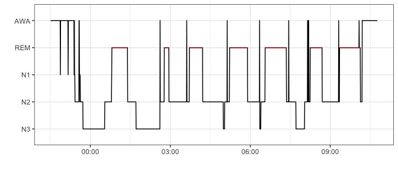

```r
library(rsleep)

events <- read_events_noxturnal("15012016HD.csv")

plot_hypnogram(events)
```

The hypnogram show sleep stages over time using consecutive 30 seconds epochs. A sleep expert scored this record visually following the guidelines from the American Association of Sleep Medicine (AASM) [2]. Five stages can be observed:

- **AWA**: Awakeness.
- **REM**: Rapid-Eye-Movement (REM) sleep, or paradoxical sleep, highlighted in red.
- **N1**: Light sleep transitional stage.
- **N2**: Light sleep.
- **N3**: Slow-wave sleep.

Visual scoring is an emprical science and requires a considerable amount of clinical knowledge. Alternative methods like spectral estimations techniques such as the Fourier transform must be used to quantify information carried in the physiological signals [5].

## Epoching

Epoching is the first step of sleep analysis. Physiological signal, such as EEG, are splitted into consecutive epochs of a discrete duration. Epochs usually start at lights turnoff, when the patient or subject starts the night.

As the example record already has a hynogram, the EEG signal can be splitted using these epochs. The `epochs` function from the `rsleep` package split the signal according to these parameters. It returns a list of signal vectors. In the example, the last scored epoch of the hypnogram finishes after the end of the signal. The hynogram dataframe must be truncated accordingly.

```r
hypnogram <- head(hypnogram(events),-2)

startTime <- as.numeric(as.POSIXct(s$startTime))

epochs <- rsleep::epochs(s$signal,s$sRate,
                         epoch = hypnogram,
                         startTime = startTime)
```

## Periodogram

The Fourier transform (FT) may be the most important function in signal analysis. It decomposes the signal into its constituent frequencies and computes its power spectral densities (PSD). A visual explanation of FT can be found on [@jezzamon](https://twitter.com/jezzamonn) website: http://www.jezzamon.com/fourier/. However, EEG signals carry a lot of noise. This noise is easily interprted by the FT and can jam the results. To solve this problem, Welch’s method split the signal into overlapping segment to average PSD from the FT.

### Single epoch

The `pwelch` function `rsleep` computes a periodogram using Welch’s method. The following computes and plot the periodogram of the 200th epoch, scored N3 by a sleep expert.

```r
p <- pwelch(epochs[[200]], sRate = s$sRate)
```

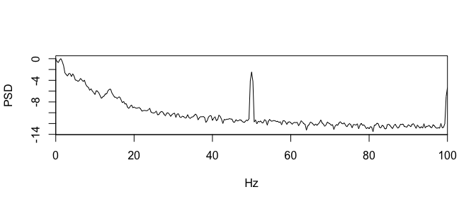

```r
summary(p)
```

```
#>        hz           psd
#>  Min.   :  0   Min.   :-13.514
#>  1st Qu.: 25   1st Qu.:-12.201
#>  Median : 50   Median :-11.473
#>  Mean   : 50   Mean   :-10.224
#>  3rd Qu.: 75   3rd Qu.: -9.617
#>  Max.   :100   Max.   :  0.000
```

This epoch periodogram shows high PSD in lower frequencies of the spectrum. The peak at 50 Hertz is an artifact caused by the power line of the PSG recorder [6]. As values are normalized using `log`, PSD are negative.

### Stages profiles

To compute average periodograms by stage, hypnogram and epochs can be iterated simultaneously using the `mapply` function. Periodograms can be filtered at this step to discard values over 30 Hertz.

```r
periodograms <- mapply(x = epochs, y = hypnogram$event, FUN = function(x,y){
  p <- pwelch(x, sRate = s$sRate, show = FALSE)
  p <- as.data.frame(p[p$hz <= 30,])
  p$stage <- y
  p
}, SIMPLIFY = F)
```

`mapply` returns a list that can be coerced to a `dataframe` using `rbind` combined to `do.call`.

```r
periodograms_df <- do.call("rbind", periodograms)
```

Once coerced to a `dataframe`, raw periodogram values can be averaged by stage.

```r
avg_periodograms <- aggregate(psd ~ hz+stage, periodograms_df, mean)
```

Aggregated periodograms can then be plotted using `ggplot2`.

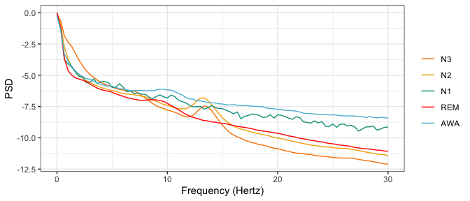

```r
library(ggplot2)

palette <- c("#F98400","#F2AD00","#00A08A","#FF0000","#5BBCD6")

ggplot(avg_periodograms, aes(x=hz,y=psd,color=stage)) +
  geom_line() + theme_bw() +
  theme(legend.title = element_blank()) +
  scale_colour_manual(name = "stage",
                      values = palette) +
  xlab("Frequency (Hertz)") + ylab("PSD")
```

Each sleep stage show a distinct average periodogram. If the `N3` stage averages higher PSD values in the lower spectrum, it show way lower PSD in the upper frequencies compared to other stages.

## Bands

The traditional way to simplify the EEG periodogram is to cut the frequencies of the spectrum into bands or ranges [1]:

- **Delta**: Below `3.5` Hertz, the Delta band is associated with slow-wave sleep in adults subjects.
- **Theta**: Between `3.5` and `7.5` Hertz, the Theta band is associated with drowsiness in adults and teens subjects.
- **Alpha**: Between `7.5` and `13` Hertz, the Alpha band is associated with a relaxed state and eyes closed.
- **Beta**: Between `13` and `30` Hertz the Beta band is associated with active thinking, focus, high alert or anxiousness.
- **Gamma**: Over `30` Hertz the Gamma band is mostly used for animal EEG analysis.

Bands can be computed using the `bands_psd` of the `rsleep` package. Those bands can be normalized by the spectrum range covered by the bands.

```r
bands <- lapply(epochs,function(x){
    bands_psd(bands = list(c(0.5,3.5), # Delta
                             c(3.5,7.5), # Theta
                             c(7.5,13), # Alpha
                             c(13,30)), # Beta
                signal = x, sRate = s$sRate,
                normalize = c(0.5,30))
})
```

As `lapply` returns a list, results must be reshaped in order to obtain a dataframe object.

```r
bands_df <- data.frame(matrix(unlist(bands), nrow=length(bands), byrow=TRUE))

colnames(bands_df) <- c("Delta","Theta","Alpha","Beta")
```

Stages can be retreived from the hypnogram.

```r
bands_df$stage <- hypnogram$event
```

Now that the epochs bands PSD and their corresponding stages are stored in a dataframe, they can easily be plotted using boxplots from `ggplot2`.

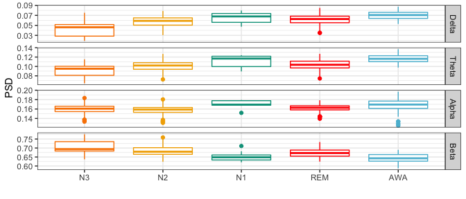

```r
bands_df_long <- reshape2::melt(bands_df, "stage")

palette <-c("#F98400", "#F2AD00", "#00A08A", "#FF0000", "#5BBCD6")

ggplot(bands_df_long,
       aes(x=stage,y=value,color=stage)) +
  geom_boxplot() +
  facet_grid(rows = vars(variable),scales = "free") +
  scale_colour_manual(name = "stage",
                      values = palette) +
  theme_bw() + xlab("") + ylab("PSD") +
  theme(legend.position = "none")
```

Each stage show a different bands PSD profile. Bands greatly simplify the EEG spectrum. However, a lot of data get lost in this aggregation process.

## Machine learning

Using periodograms, would it be possible to automatically classify stages of a sleep record from a single channel EEG?

The example record can be divided into a training set and a testing set. 70% of the epochs periodograms can be used to train a random forest to classify stages. Then, an accuracy score can be computed using the 30% left, not used during the training step.

Others algorithm, such as multitapers, can be used to estimate PSD. The R package `psd` implements the adaptive, Sine-Multitaper Power Spectral Density Estimation from a method described by Riedel and Sidorenko [7] [8].

The `psm` method from `rsleep` conveniently encapsulate this algorithm to return the periodogram as a dataframe. As for the previous example, it can be called using `mapply` to also iterate over hypnogram stages. As periodograms will be used for machine learning, the matrix must be in a wide format, thus an additional call to the transpose method `t`.

```r
features <- mapply(x = epochs, y = hypnogram$event,
             FUN = function(x,y){
  periodogram <- psm(x, sRate = s$sRate, 200)
  periodogram <- periodogram[periodogram$hz <= 30,]
  periodogram <- setNames(t(periodogram)[1,], t(periodogram)[2,])
  periodogram <- c(periodogram, setNames(y,"stage"))
}, SIMPLIFY = F)
```

```
#> Loaded psd (1.2.0) -- Adaptive multitaper spectrum estimation
```

```r
features <- as.data.frame(do.call("rbind", features))

features$stage <- as.factor(features$stage)
```

The `features` dataframe contains values for each periodogram and an additional `stage` column containing the stage level. But before training a random forest model, this dataframe must be splitted into the train and test set. This can be done using `createDataPartition` from the `caret` package.

```r
set.seed(12345)

library(caret)
inTrain <- createDataPartition(features$stage, p=0.70, list=F)

training <- features[inTrain,]
validation <- features[-inTrain,]
```

Using 3 folds cross-validation, `train` function from the `caret` package fits the random forest over the training set.

```r
control <- caret::trainControl(method="cv", 3, allowParallel = TRUE)

fit <- train(stage ~ ., training, method= 'rf', trControl = control)
```

Once model has been trained, stages can be predicted from the testing set using the `predict` function.

```r
results <- predict(fit, validation)
```

Cohen’s Kappa score is very suitable to evaluates the model quality of predicition. Cohen’s Kappa measures inter-rater reliability for qualitative [9]. Originally designed for evaluation of reliability in the domain of psychology, an implementation of the Cohen’s Kappa score can be found in the `psy` R package.

```r
library(psy)

ckappa(cbind(results,validation$stage))
```

```
#> $table
#>    1   2 3   4  5
#> 1 68   1 0   0  0
#> 2  8 141 1   4  1
#> 3  0   0 0   0  0
#> 4  0  19 1 135  0
#> 5  0   1 0   3 54
#>
#> $kappa
#> [1] 0.8741425
```

Score is very high, showing the model is reliable in this case. However, training and testing sets would be recorded on different subjects in real life, as EEG profiles significantly differ between different subjects. Recent neural networks architectures show similar results on large scale, pathological patients datasets [10] [11].

## References

[1] E. Niedermeyer, F.H. Lopes da Silva, eds., Electroencephalography: Basic principles, clinical applications, and related fields, 5th ed, Lippincott Williams & Wilkins, Philadelphia, 2005.

[2] AASM Scoring Manual - American Academy of Sleep Medicine, American Academy of Sleep Medicine Association for Sleep Clinicians and Researchers. (n.d.).

[3] V. Ibáñez, J. Silva, O. Cauli, A survey on sleep assessment methods, PeerJ. 6 (2018) e4849. doi:10.7717/peerj.4849.

[4] B. Kemp, A. Värri, A.C. Rosa, K.D. Nielsen, J. Gade, A simple format for exchange of digitized polygraphic recordings, Electroencephalography and Clinical Neurophysiology. 82 (1992) 391–393. doi:10.1016/0013-4694(92)90009-7.

[5] S. Tong, N.V. Thakor, eds., Quantitative EEG analysis methods and clinical applications, Artech House, Boston, 2009.

[6] S. Motamedi-Fakhr, M. Moshrefi-Torbati, M. Hill, C.M. Hill, P.R. White, Signal processing techniques applied to human sleep EEG signalsA review, Biomedical Signal Processing and Control. 10 (2014) 21–33. doi:10.1016/j.bspc.2013.12.003.

[7] A.J. Barbour, R.L. Parker, Psd: Adaptive, sine multitaper power spectral density estimation for R, Computers & Geosciences. 63 (2014) 1–8. doi:10.1016/j.cageo.2013.09.015.

[8] K.S. Riedel, A. Sidorenko, Minimum bias multiple taper spectral estimation, IEEE Transactions on Signal Processing. 43 (n.d.) 188–195. doi:10.1109/78.365298.

[9] J. Cohen, A Coefficient of Agreement for Nominal Scales, Educational and Psychological Measurement. 20 (1960) 37–46. doi:10.1177/001316446002000104.

[10] S. Chambon, M. Galtier, P. Arnal, G. Wainrib, A. Gramfort, A deep learning architecture for temporal sleep stage classification using multivariate and multimodal time series, arXiv:1707.03321 [Cs, Q-Bio, Stat]. (2017). http://arxiv.org/abs/1707.03321.

[11] J.B. Stephansen, A.N. Olesen, M. Olsen, A. Ambati, E.B. Leary, H.E. Moore, O. Carrillo, L. Lin, F. Han, H. Yan, Y.L. Sun, Y. Dauvilliers, S. Scholz, L. Barateau, B. Hogl, A. Stefani, S.C. Hong, T.W. Kim, F. Pizza, G. Plazzi, S. Vandi, E. Antelmi, D. Perrin, S.T. Kuna, P.K. Schweitzer, C. Kushida, P.E. Peppard, H.B.D. Sorensen, P. Jennum, E. Mignot, Neural network analysis of sleep stages enables efficient diagnosis of narcolepsy, Nature Communications. 9 (2018). doi:10.1038/s41467-018-07229-3.